# Current State of Expungeable Records SCRAPS

Seth Green

3/15/2021

```r
# first you need to install these packages
library(httr)
library(tidyverse)
library(data.table)
library(fs)
```

# Connecting to the data

Here we’ll have a function to pull in the data, ideally for a single year. This one works to get a 1000 row sample, but we’ll rewrite this once we’re on the server to just hit the csv’s directly.

```r
pull_table_sample <- function(.table) {
  endpoint <- "http://132.145.211.20:8001/criminal-court.csv?"
  my_query <- paste("select * from", .table)
  request <- GET(url = endpoint,
              query = list(
                sql = my_query
              ))
  read_csv(content(request, as = "text", encoding = "UTF-8"))
}
```

And now pull a sample for demo:

```r
sample_data <- pull_table_sample("circuit_criminal_2019_anon_00")
print(nrow(sample_data))
```

```
## [1] 1000
```

```r
head(sample_data)
```

```
## # A tibble: 6 x 50
##   HearingDate HearingResult      HearingJury HearingPlea HearingType HearingRoom
##   <date>      <chr>              <lgl>       <chr>       <chr>       <chr>
## 1 2019-12-17  Revoked - Sentenc… NA          <NA>        Revocation  <NA>
## 2 2019-12-17  Sentenced          NA          <NA>        Trial       <NA>
## 3 2019-10-30  Granted            NA          <NA>        Review      <NA>
## 4 2019-10-30  <NA>               NA          <NA>        Review      <NA>
## 5 2019-10-30  Continued General… NA          <NA>        Show Cause  <NA>
## 6 2019-10-30  Dismissed          NA          <NA>        Sentencing  <NA>
## # … with 44 more variables: fips <dbl>, Filed <date>, Commencedby <chr>,
## #   Locality <chr>, Sex <chr>, Race <chr>, Address <chr>, Charge <chr>,
## #   CodeSection <chr>, ChargeType <chr>, Class <chr>, OffenseDate <date>,
## #   ArrestDate <date>, DispositionCode <chr>, DispositionDate <date>,
## #   ConcludedBy <chr>, AmendedCharge <chr>, AmendedCodeSection <chr>,
## #   AmendedChargeType <chr>, JailPenitentiary <chr>,
## #   ConcurrentConsecutive <chr>, LifeDeath <lgl>, SentenceTime <dbl>,
## #   SentenceSuspended <dbl>, OperatorLicenseSuspensionTime <dbl>,
## #   FineAmount <dbl>, Costs <dbl>, FinesCostPaid <lgl>, ProgramType <chr>,
## #   ProbationType <chr>, ProbationTime <dbl>, ProbationStarts <chr>,
## #   CourtDMVSurrender <chr>, DriverImprovementClinic <lgl>,
## #   DrivingRestrictions <lgl>, RestrictionEffectiveDate <date>,
## #   RestrictionEndDate <date>, VAAlcoholSafetyAction <lgl>,
## #   RestitutionPaid <lgl>, RestitutionAmount <dbl>, Military <chr>,
## #   TrafficFatality <lgl>, AppealedDate <date>, person_id <dbl>
```

### The full data

The full data is pretty big. Here we filter to the files we care about and then we’ll read them one-by-one below.

```r
criminal_files <- fs::dir_ls("/home/rstudio/courtdata") %>% str_subset("criminal")
length(criminal_files)
```

```
## [1] 119
```

Here are two helper functions to pull in only the columns we need. We also rename some of them in the district court files, in order to be consistent with the naming in the circuit court files.

```r
read_district_file <- function(.f) {
  fread(
  .f,
  select = c(
    "HearingDate",
    "person_id",
    "CodeSection",
    "FinalDisposition",
    "CaseType",
    "Charge"
  )
) %>%
  rename(
    DispositionCode = FinalDisposition,
    ChargeType = CaseType
  ) %>%
  mutate(
      CourtType = "district"
    )
}

read_circuit_file <- function(.f) {
  fread(
    .f,
    select = c(
      "HearingDate",
      "person_id",
      "CodeSection",
      "DispositionCode",
      "ChargeType",
      "Charge"
    )
  ) %>%
    mutate(
      CourtType = "circuit"
    )
}
```

# Filter to expungeable cases

This is the real analysis section, we’re we filter down to the cases that we care about.

### Defining the cases we care about

- `reference` – the section of the new law describing a specific category of case that is expungeable.
- `title` – a free text sample from that section of the new law, for explanatory purposes.
- Any applicable filters. These elements each contain values that the specified field is allowed to take:
  - `CodeSection` – The codes for the alleged crime
  - `DispositionCode` – The relevant dispositions of the cases for the relevant crimes
  - `ChargeType` – The relevant charge type (“Felony”, “Misdemeanor”, etc.) if relevant

**NOTE: this may be a partial list.** We should probably go through the new law again with an LAJC lawyer to make sure we have coded this correctly.

Under the old law, any cases with the following dispositions should be eligible for expungement.

```r
OLD_LAW <- c(
      "Dismissed",
      "Dismissed/Other",
      "Nolle Prosequi",
      "Not Guilty/Acquitted",
      "Not Guilty By Reason Of Insanity",
      "Not True Bill",
      "Not Guilty",
      "Not Guilty/Insanity"
    )
```

### Code to filter to those cases

```r
#' Filter the input data based on a query
#' @param .d A tibble of the criminal court data
#' @param .q A "query list" as defined in the section above.
filter_on_query <- function(.d, .q) {
  .d %>%
    filter(
      CodeSection %in% (.q$CodeSection %||% CodeSection),
      DispositionCode %in% (.q$DispositionCode %||% DispositionCode),
      ChargeType %in% (.q$ChargeType %||% ChargeType)
    ) %>%
    mutate(
      reference = .q$reference,
      title = .q$title
    ) %>%
    select(
      reference,
      title,
      HearingDate,
      person_id,
      CodeSection,
      DispositionCode,
      ChargeType,
      Charge
    )
}
```

Here we map over the queries to get only the relevant cases that fit *any* of our queries. This is only the sample data. We pull in all of the data below.

```r
purrr::map_dfr(QUERIES, function(.query) {
  filter_on_query(sample_data, .query)
}) %>%
  select(
    reference,
    CodeSection,
    DispositionCode,
    ChargeType,
    Charge
  ) %>% knitr::kable()
```

| reference | CodeSection | DispositionCode | ChargeType | Charge |
| --- | --- | --- | --- | --- |
| 19.2-392.6.B | 18.2-96 | Guilty | Misdemeanor | PETIT LARC <$500 NOT FRM PERSN |
| 19.2-392.6.B | 18.2-96 | Guilty | Misdemeanor | PETIT LARC <$500 NOT FRM PERSN |
| 19.2-392.6.B | 18.2-96 | Guilty | Misdemeanor | PETIT LARC <$500 NOT FRM PERSN |
| 19.2-392.6.B | 18.2-96 | Guilty | Misdemeanor | PETIT LARC <$500 NOT FRM PERSN |
| 19.2-392.6.B | 18.2-103 | Guilty | Felony | SHOPLFT:ALTER PRICE <$200 (3+) |
| 19.2-392.6.B | 18.2-96 | Guilty | Felony | PETIT LARCENY <$5 PICKPOCKET |
| 19.2-392.6.B | 18.2-103 | Guilty | Misdemeanor | SHOPLIFT/ ALTER MERCH<$500 |
| 19.2-392.6.B | 18.2-96 | Guilty | Felony | PETIT LARCENY <$5 PICKPOCKET |
| 19.2-392.6.B | 18.2-96 | Guilty | Felony | PETIT LARCENY <$5 PICKPOCKET |
| 19.2-392.6.B | 18.2-103 | Guilty | Felony | SHOPLFT:ALTER PRICE <$500 (3+) |
| 19.2-392.6.B | 18.2-96 | Guilty | Felony | PETIT LARCENY <$5 PICKPOCKET |
| 19.2-392.6.B | 18.2-103 | Guilty | Felony | SHOPLFT:ALTER PRICE <$200 (3+) |
| 19.2-392.6.B | 18.2-103 | Guilty | Felony | SHOPLFT:ALTER PRICE <$200 (3+) |
| 19.2-392.6.B-misdemeanor | 18.2-250.1 | Guilty | Misdemeanor | POSSESSION OF MARIJUANA |
| 19.2-392.6.B-misdemeanor | 18.2-248.1 | Guilty | Misdemeanor | SALE, DISTRIBUTE MARIJUANA |
| 19.2-392.12 | 18.2-57.2 | Dismissed | Misdemeanor | ASSAULT & BATTERY-FAM MEMBER |

## The full data, summarized by year

This is where we roll it up to what they are likely looking for: by year, how many cases are eligible for expungement and why? For the “and why?” part, we give them the reference section in the new law.

```r
years <- as.character(2009:2019)
years_files <- unlist(map(years, ~str_subset(criminal_files, .x)))

# writing out counts as we iterate in purrr
write_lines("file,year,total,old_law,new_law", "counts.csv")
message(paste("Iterating over", length(years_files), "for", length(years), "years..."))
```

```
## Iterating over 108 for 11 years...
```

```r
all_df <- purrr::map_dfr(years_files, function(.y) {
  message(paste("Parsing", .y))

  if (str_detect(.y, "circuit")) {
    this_df <- read_circuit_file(.y)
  } else {
    this_df <- read_district_file(.y)
  }

  # get some counts to write out
  total <- nrow(this_df)
  old_law <- this_df %>%
    filter(DispositionCode %in% OLD_LAW) %>%
    nrow()

  # parse the year out of the file name
  this_year <- .y %>%
    str_replace(".+criminal_", "") %>%
    str_replace("_anon.+$", "")

  # filter to only the rows that match one of our queries
  new_law_df <- purrr::map_dfr(QUERIES, function(.query) {
    filter_on_query(this_df, .query)
  }) %>%
    mutate(
      year = this_year,
      file = .y
    )

  # write out the counts
  write_lines(
    paste(.y, this_year, total, old_law, nrow(new_law_df), sep=","),
    "counts.csv",
    append=TRUE
  )

  return(new_law_df)
})
```

[output not shown]

[output not shown]

[output not shown]

[output not shown]

[output not shown]

[output not shown]

[output not shown]

[output not shown]

[output not shown]

[output not shown]

[output not shown]

[output not shown]

[output not shown]

[output not shown]

[output not shown]

[output not shown]

[output not shown]

[output not shown]

[output not shown]

[output not shown]

[output not shown]

[output not shown]

[output not shown]

[output not shown]

[output not shown]

[output not shown]

[output not shown]

[output not shown]

[output not shown]

[output not shown]

[output not shown]

[output not shown]

[output not shown]

[output not shown]

[output not shown]

[output not shown]

[output not shown]

[output not shown]

[output not shown]

[output not shown]

[output not shown]

[output not shown]

[output not shown]

[output not shown]

[output not shown]

[output not shown]

[output not shown]

[output not shown]

[output not shown]

[output not shown]

[output not shown]

[output not shown]

[output not shown]

[output not shown]

[output not shown]

[output not shown]

[output not shown]

[output not shown]

[output not shown]

[output not shown]

[output not shown]

[output not shown]

[output not shown]

[output not shown]

[output not shown]

[output not shown]

[output not shown]

[output not shown]

[output not shown]

[output not shown]

[output not shown]

[output not shown]

[output not shown]

[output not shown]

[output not shown]

[output not shown]

[output not shown]

[output not shown]

[output not shown]

[output not shown]

[output not shown]

[output not shown]

[output not shown]

[output not shown]

[output not shown]

[output not shown]

[output not shown]

[output not shown]

[output not shown]

[output not shown]

[output not shown]

[output not shown]

[output not shown]

[output not shown]

[output not shown]

[output not shown]

[output not shown]

[output not shown]

[output not shown]

[output not shown]

[output not shown]

[output not shown]

[output not shown]

[output not shown]

[output not shown]

[output not shown]

[output not shown]

[output not shown]

```r
nrow(all_df)
```

```
## [1] 516559
```

## Results for the New Law

Total counts of *newly expungeable* cases by year:

```r
all_df %>%
  count(year) %>%knitr::kable()
```

| year | n |
| --- | --- |
| 2009 | 51348 |
| 2010 | 50834 |
| 2011 | 49932 |
| 2012 | 50755 |
| 2013 | 51464 |
| 2014 | 49177 |
| 2015 | 45464 |
| 2016 | 41502 |
| 2017 | 40723 |
| 2018 | 42358 |
| 2019 | 43002 |

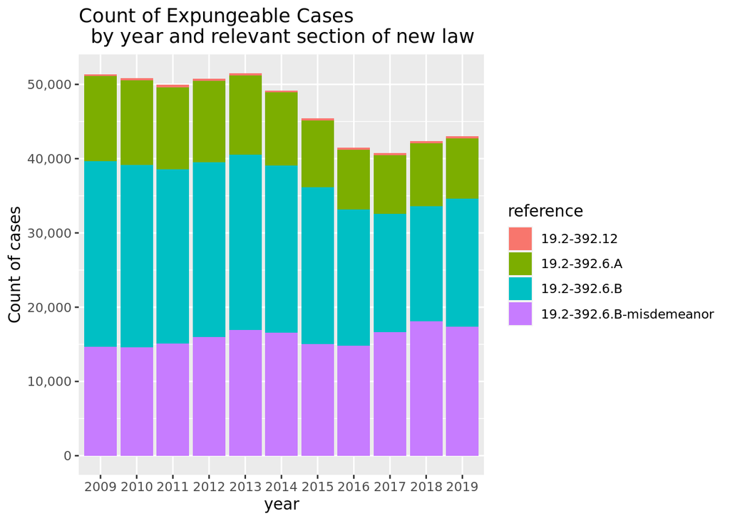

```r
all_df %>%
  count(year, reference) %>%
  ggplot(aes(x = year, y = n, fill = reference)) +
    geom_bar(stat = "identity") +
    scale_y_continuous(labels=function(x) format(x, big.mark = ",", scientific = FALSE)) +
    ylab("Count of cases") +
    ggtitle("Count of Expungeable Cases\n  by year and relevant section of new law")
```

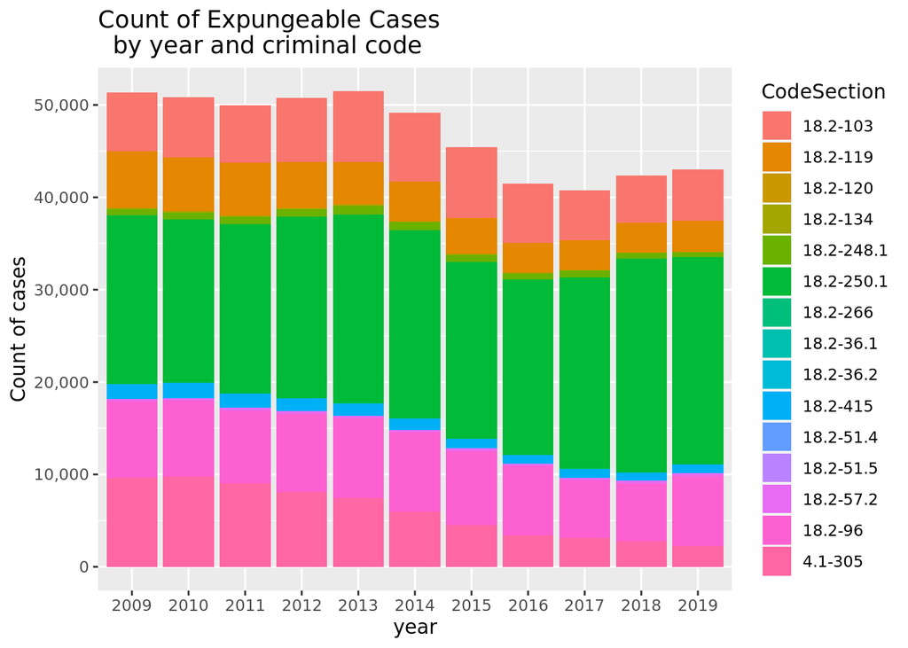

```r
all_df %>%
  count(year, CodeSection) %>%
  ggplot(aes(x = year, y = n, fill = CodeSection)) +
    geom_bar(stat = "identity") +
    scale_y_continuous(labels=function(x) format(x, big.mark = ",", scientific = FALSE)) +
    ylab("Count of cases") +
    ggtitle("Count of Expungeable Cases\n  by year and criminal code")
```

## Percentage of total cases that are expungeable (under new law vs old law)

This compares the number of additional cases that will be expungeable under the new law vs. the number of cases that were previously expungeable (*but should now be automatic?*).

```r
counts_df <- read_csv("counts.csv", col_types = cols()) %>%
  group_by(year) %>%
  summarize(
    total = sum(total),
    new_law = sum(new_law),
    old_law = sum(old_law)
  ) %>%
  pivot_longer(
    cols = ends_with("law"),
    names_to = "Eligibility",
    values_to = "raw_count"
  ) %>%
  mutate(
    Percent = scales::percent(raw_count/total, accuracy = 0.1),
    Count = format(raw_count, big.mark = ",")
  )
```

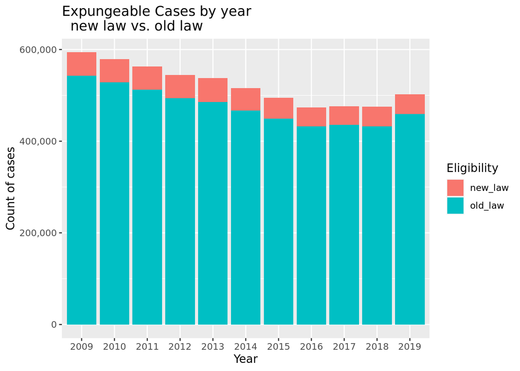

```r
ggplot(counts_df, aes(x = as.factor(year), y = raw_count, fill = Eligibility)) +
  geom_bar(stat = "identity") +
  scale_y_continuous(labels=function(x) format(x, big.mark = ",", scientific = FALSE)) +
  xlab("Year") + ylab("Count of cases") +
  ggtitle("Expungeable Cases by year\n  new law vs. old law")
```

The `Percent` column shows the percentage of total cases for that year that fall into each category.

```r
counts_df %>%
  select(year, Eligibility, Count, Percent) %>%
  knitr::kable(align = "r")
```

| year | Eligibility | Count | Percent |
| --- | --- | --- | --- |
| 2009 | new_law | 51,348 | 2.0% |
| 2009 | old_law | 542,491 | 20.6% |
| 2010 | new_law | 50,834 | 2.0% |
| 2010 | old_law | 528,055 | 20.6% |
| 2011 | new_law | 49,932 | 2.0% |
| 2011 | old_law | 512,694 | 20.7% |
| 2012 | new_law | 50,755 | 2.1% |
| 2012 | old_law | 493,657 | 20.4% |
| 2013 | new_law | 51,464 | 2.2% |
| 2013 | old_law | 485,856 | 20.3% |
| 2014 | new_law | 49,177 | 2.1% |
| 2014 | old_law | 466,768 | 20.1% |
| 2015 | new_law | 45,464 | 2.1% |
| 2015 | old_law | 448,924 | 20.9% |
| 2016 | new_law | 41,502 | 2.0% |
| 2016 | old_law | 432,458 | 21.3% |
| 2017 | new_law | 40,723 | 2.0% |
| 2017 | old_law | 435,669 | 20.9% |
| 2018 | new_law | 42,358 | 2.1% |
| 2018 | old_law | 432,647 | 21.0% |
| 2019 | new_law | 43,002 | 2.0% |
| 2019 | old_law | 459,581 | 21.2% |